# Flujo de trabajo integrado para elaborar el estado del arte

Síntesis metodológica operativa para revisión, mapeo bibliométrico y evaluación crítica

Ph.D. Pablo Eduardo Caicedo Rodríguez

2024-08-12

## Propósito central

- El documento propone un **flujo integrado de seis fases** para construir un estado del arte con trazabilidad metodológica.
- La tesis principal es directa: un estado del arte riguroso **no equivale a buscar artículos y resumirlos**.
- El valor del flujo está en **encadenar diseño, búsqueda, depuración, análisis cuantitativo, evaluación crítica y síntesis**.
- Los ejemplos incluidos en el documento son **ilustrativos**; no deben interpretarse como resultados empíricos reales.

## Qué es y qué no es un estado del arte riguroso

| Sí es | No es |
| --- | --- |
| Síntesis científica con reglas explícitas de búsqueda, selección e interpretación | Enumeración bibliográfica o cronología de artículos |
| Proceso auditable que identifica patrones, vacíos y controversias | Revisión narrativa sin criterios transparentes |
| Integración de capas cuantitativas y críticas | Sustituto automático de una revisión sistemática completa |
| Base para decisiones de investigación futuras | Acumulación de referencias sin justificación metodológica |

- Debe responder al menos cinco cuestiones: temas dominantes, métodos predominantes, evidencia más robusta, contradicciones persistentes y trayectorias prometedoras.

## Arquitectura general del flujo

```
flowchart TD
  A["(1) Planificación y protocolo"] --> B["(2) Ingeniería de búsqueda"]
  B --> C["(3) Análisis bibliométrico"]
  C --> D["(4) Selección y evaluación"]
  D --> E["(5) Síntesis del estado del arte"]
  E --> F["(6) Discusión y conclusiones"]

  B -. "recalibración" .-> A
  C -. "ajuste de búsqueda" .-> B
  D -. "redefine criterios operativos" .-> B
  E -. "completa variables faltantes" .-> D
```

- Cada fase produce insumos para la siguiente.
- Una decisión débil al inicio contamina todo el informe final.

## Qué produce cada fase y qué se arriesga si falla

| Fase | Propósito central | Producto principal | Riesgo si se ejecuta mal |
| --- | --- | --- | --- |
| Planificación y protocolo | Delimitar el problema y fijar reglas previas | Protocolo de revisión | Arbitrariedad y sesgo de decisión |
| Ingeniería de búsqueda | Recuperar evidencia relevante con trazabilidad | Estrategias por base de datos | Pérdida de estudios clave o exceso de ruido |
| Análisis bibliométrico | Describir la estructura cuantitativa del campo | Mapas, indicadores y clústeres | Interpretación superficial del dominio |
| Selección y evaluación | Identificar estudios elegibles y valorar su calidad | Muestra final + evaluación crítica | Inclusión de evidencia defectuosa |
| Síntesis | Integrar hallazgos de forma comparativa | Síntesis narrativa estructurada | Resumen cronológico sin capacidad analítica |
| Discusión y conclusiones | Convertir la síntesis en conocimiento útil | Informe final | Conclusiones vagas o no sustentadas |

## Fase 1: planificación y protocolo

- Su función es **epistemológica**, no burocrática.
- Fija la pregunta, los criterios de elegibilidad y el plan de análisis **antes** de buscar.
- Reduce el riesgo de adaptar reglas según lo que va apareciendo.
- Convierte una revisión reactiva en una revisión **auditable**.

**Entregables mínimos**

- Protocolo escrito
- Pregunta refinada
- Matriz de elegibilidad
- Lista preliminar de conceptos de búsqueda

## De pregunta amplia a pregunta operativa

> En pacientes con glioblastoma evaluados mediante imágenes de resonancia magnética, ¿los modelos con componentes causales o mecanismos explícitos de robustez muestran mejor generalización intercentro que los modelos puramente asociativos para tareas de segmentación tumoral?

| Componente | Formulación operativa |
| --- | --- |
| Población | Pacientes con glioblastoma o imágenes de glioblastoma |
| Intervención o exposición | Modelos causales, modelos robustos, inferencia causal, generalización |
| Comparador | Modelos asociativos, modelos de caja negra, aprendizaje profundo convencional |
| Resultado | Segmentación, robustez, generalización, desempeño fuera del centro de entrenamiento |

## Criterios de elegibilidad: pertinencia temática no basta

| Dimensión | Inclusión | Exclusión |
| --- | --- | --- |
| Tema | Segmentación de glioblastoma en resonancia magnética | Otras neoplasias sin segmento específico de glioblastoma |
| Tipo de publicación | Artículos completos revisados por pares | Resúmenes sin metodología completa, editoriales o cartas |
| Periodo | Intervalo definido en el protocolo | Fuera del periodo establecido |
| Idioma | Idiomas definidos en el protocolo | Idiomas no contemplados |
| Método | Modelos computacionales con descripción suficiente | Descripciones vagas, sin detalle de arquitectura o datos |
| Evaluación | Métricas relevantes para segmentación | Métricas insuficientes o ambiguas |

- En dominios técnicos también importa si la validación es reproducible, si los datos están descritos y si las métricas son pertinentes.

## Fase 2: ingeniería de ecuaciones de búsqueda

**Lógica técnica**

- Traducir la pregunta a ecuaciones con equilibrio entre **sensibilidad** y **precisión**.
- Descomponer la pregunta en conceptos y usar dos capas terminológicas:
  - vocabulario controlado
  - lenguaje natural
- No todos los componentes deben entrar en la ecuación maestra.

| Pilar conceptual | Términos de texto libre |
| --- | --- |
| Modalidad de imagen | magnetic resonance imaging, MRI, brain MRI |
| Fenómeno o entidad | glioblastoma, brain tumor, brain tumour, glioma |
| Tarea computacional | segmentation, image segmentation, tumor delineation |
| Enfoque metodológico | causal AI, causal inference, robust segmentation, domain generalization |

## La búsqueda se calibra: no se redacta una sola vez

```
flowchart TD
  P[Pregunta refinada] --> T[Taxonomía de términos]
  T --> E[Ecuación inicial]
  E --> S[Prueba con artículos semilla]
  E --> R[Revisión de ruido]
  S --> A[Ajuste de sinónimos, campos y operadores]
  R --> A
  A --> E
  A --> D[Documentación final]
```

- **Sensibilidad**: si no recupera artículos indispensables, la ecuación es insuficiente.
- **Precisión**: si los primeros resultados son mayoritariamente irrelevantes, la ecuación es demasiado amplia.
- Deben registrarse al menos: base, estrategia exacta, filtros, fecha y número de resultados.

## Fase 3: bibliometría como capa cuantitativa

```
flowchart LR
  A[Registros consolidados] --> B[Actividad]
  A --> C[Impacto]
  A --> D[Co-citación]
  A --> E[Co-ocurrencia de palabras clave]
  A --> F[Coautoría]
```

- **Actividad**: cuánto, quién y dónde se publica.
- **Impacto**: influencia medida por citaciones e índice H.
- **Mapeo científico**:
  - estructura intelectual: co-citación
  - estructura conceptual: co-ocurrencia
  - estructura social: coautoría

**Indicador ejemplar**

$$\text{Tasa de crecimiento anual}=
\frac{N_t - N_{t-1}}{N_{t-1}} \times 100$$

- $N_t$: número de documentos del año actual
- $N_{t-1}$: número de documentos del año anterior
- Productividad no equivale a solidez metodológica.

## Flujo computacional sugerido para la bibliometría

```
proyecto_estado_arte/
├── 01_protocolo/
├── 02_busqueda/
├── 03_registros_crudos/
├── 04_limpieza_y_deduplicacion/
├── 05_bibliometria/
├── 06_screening/
├── 07_extraccion_datos/
├── 08_sintesis/
└── 09_informe/
```

1. Exportar registros desde las bases de datos
2. Consolidar y deduplicar
3. Normalizar nombres y términos
4. Generar indicadores de producción e impacto
5. Construir redes de co-citación, co-ocurrencia y coautoría
6. Interpretar los patrones sin confundir popularidad con validez

## Fase 4: selección y evaluación crítica

```
flowchart TD
  A[Registros recuperados] --> B[Deduplicación]
  B --> C[Tamizaje de título y resumen]
  C --> D[Revisión a texto completo]
  D --> E[Extracción de datos]
  D --> F[Evaluación de calidad y riesgo de sesgo]
  E --> G[Estudios utilizables para síntesis]
  F --> G
```

- La deduplicación debe combinar identificador digital y coincidencia de título-año.
- El tamizaje elimina irrelevancia evidente; no resuelve todavía debates finos de calidad.
- La revisión a texto completo verifica elegibilidad real y suficiencia técnica.
- En estudios computacionales importan especialmente: fuga de datos, validación externa, métricas adecuadas y transparencia del preprocesamiento.

## Qué vuelve utilizable a un estudio computacional

| Criterio | Estudio A | Estudio B |
| --- | --- | --- |
| Descripción del conjunto de datos | Clara, con origen y tamaño especificados | Vaga, sin procedencia clara |
| Separación entrenamiento-prueba | Conjunto externo independiente | No queda claro; posible fuga de datos |
| Métricas reportadas | Dice, sensibilidad, precisión, intervalos de confianza | Solo exactitud global |
| Preprocesamiento | Normalización y remuestreo bien descritos | No descrito |
| Juicio preliminar | Evidencia utilizable | Riesgo alto de sesgo |

## Fase 5: la síntesis compara familias, no artículos aislados

| Grupo de estudios | Rasgo común | Métrica principal | Hallazgo dominante | Limitación recurrente |
| --- | --- | --- | --- | --- |
| Variantes de U-Net | Arquitectura convolucional de segmentación | Coeficiente Dice | Buen desempeño en entornos controlados | Menor discusión de generalización |
| Transformadores | Modelos con mecanismos de atención | Coeficiente Dice y distancia de bordes | Tendencia a mejorar la representación global | Mayor demanda de datos y cómputo |
| Modelos causales o robustos | Mecanismos orientados a estabilidad | Generalización y caída de rendimiento intercentro | Mejor estabilidad fuera del dominio original | Menor volumen de estudios |

- La síntesis debe agrupar por dimensiones comparables: arquitectura, función de pérdida, datos o estrategia de validación.
- El error clásico es describir estudio por estudio sin construir contraste analítico.

## Certeza de la evidencia y visualización cualitativa

**Factores que disminuyen la certeza**

- Fuga de datos
- Inconsistencia entre estudios
- Evidencia indirecta
- Imprecisión por muestras pequeñas

**Factores que pueden aumentarla**

- Magnitud del efecto
- Patrón consistente entre estudios independientes
- Mejor estabilidad fuera del dominio original
- Descripción clara de datos y validaciones
- Cuando no es viable un metaanálisis, el documento recomienda una **síntesis narrativa estructurada**.
- Para condensar heterogeneidad, propone **diagramas de cosecha** y **gráficos de burbujas** como apoyo visual de la interpretación.

## Fase 6: de la síntesis a conclusiones útiles

```
flowchart LR
  A[Resumen de hallazgos] --> B[Brechas de conocimiento]
  B --> C[Limitaciones de la revisión]
  C --> D[Implicaciones para investigación y desarrollo]
```

- La discusión no repite resultados: los **interpreta**.
- Debe separar con claridad:
  - frecuencia de aparición
  - solidez metodológica
  - vacíos accionables
- Una brecha útil es específica, por ejemplo: escasez de validación intercentro, opacidad del preprocesamiento o ausencia de comparaciones justas.

## Integración transversal: las fases no son compartimentos aislados

| Si falla esta fase | Se afecta principalmente | Consecuencia |
| --- | --- | --- |
| Planificación | Búsqueda y selección | Criterios ambiguos y sesgo de alcance |
| Búsqueda | Bibliometría y selección | Muestra incompleta o contaminada |
| Bibliometría | Discusión estratégica | Panorama deformado del campo |
| Selección | Síntesis y conclusiones | Evidencia no confiable o insuficiente |
| Extracción | Síntesis | Comparaciones pobres o imposibles |
| Síntesis | Discusión final | Conclusiones descriptivas y débiles |

- La ejecución real requiere retroalimentación, control de versiones y bitácora de decisiones.

## Plantillas operativas y aplicaciones prácticas

| Plantilla | Uso |
| --- | --- |
| Protocolo inicial | Justificación, pregunta, objetivos, criterios, fuentes, búsqueda, evaluación y síntesis |
| Formulario de screening | Decisiones en título y resumen |
| Evaluación a texto completo | Verificación técnica y riesgo de sesgo |
| Síntesis final | Comparación entre grupos metodológicos |

**Aplicaciones prácticas**

- Estados del arte en investigación formativa o de posgrado
- Capítulos de antecedentes en tesis y artículos
- Revisiones sistemáticas con componente bibliométrico
- Panoramas robustos en áreas técnicas con alta producción científica

## Errores frecuentes y cómo evitarlos

- **Pregunta demasiado amplia** -> delimitar problema, contexto y resultado de interés.
- **Confundir cantidad de artículos con calidad** -> medir pertinencia y trazabilidad, no volumen bruto.
- **Usar bibliometría como sustituto de lectura crítica** -> recordar que redes y citaciones no evalúan sesgo.
- **Sintetizar artículo por artículo** -> agrupar por dimensiones comparables.
- **No declarar limitaciones** -> reconocer restricciones metodológicas mejora la honestidad del informe.

## Límites documentales y puntos pendientes

- El documento ofrece una estructura metodológica sólida, ejemplos temáticos y nombres de estándares relevantes.
- No incorpora los instrumentos completos de evaluación, las listas oficiales de verificación ni una bibliografía detallada de soporte.
- Los ejemplos del texto sirven para mostrar la lógica del flujo, no para reportar hallazgos empíricos reales.
- Pendiente técnico: información insuficiente en los PDF adjuntos para completar esta sección.

## Mensajes clave de cierre

- Un estado del arte sólido es una **cadena de decisiones metodológicas explícitas**.
- La bibliometría aporta contexto estructural, pero **no reemplaza** la evaluación crítica.
- La síntesis útil compara familias de estudios, juzga certeza y formula brechas accionables.
- El flujo es especialmente pertinente en dominios técnicos con rápido crecimiento y heterogeneidad metodológica.

## Referencias

- [1] M. J. Page et al., “PRISMA 2020 explanation and elaboration: updated guidance and exemplars for reporting systematic reviews”, BMJ, p. n160, mar. 2021, doi: 10.1136/bmj.n160.
- [2] D. A. Korevaar, P. M. Bossuyt, M. D. F. McInnes, y J. F. Cohen, “PRISMA-DTA for Abstracts: a new addition to the toolbox for test accuracy research”, Diagn Progn Res, vol. 5, núm. 1, pp. 8, s41512-021-00097–4, dic. 2021, doi: 10.1186/s41512-021-00097-4.
- [3] M. Campbell et al., “Synthesis without meta-analysis (SWiM) in systematic reviews: reporting guideline”, BMJ, p. l6890, ene. 2020, doi: 10.1136/bmj.l6890.
- [4] J. Higgins et al., Cochrane Handbook for Systematic Reviews of Interventions, 2nd ed. en Wiley Cochrane. Newark: John Wiley & Sons, Incorporated, 2019.
- [5] PRISMA-P Group et al., “Preferred reporting items for systematic review and meta-analysis protocols (PRISMA-P) 2015 statement”, Syst Rev, vol. 4, núm. 1, p. 1, dic. 2015, doi: 10.1186/2046-4053-4-1.
- [6] G. Guyatt et al., “GRADE guidelines: 1. Introduction—GRADE evidence profiles and summary of findings tables”, Journal of Clinical Epidemiology, vol. 64, núm. 4, pp. 383–394, abr. 2011, doi: 10.1016/j.jclinepi.2010.04.026.

## Propósito del ejemplo

Este material muestra cómo aplicar el flujo de trabajo de estado del arte a un caso completo, pero **simulado**.

El tema usado como hilo conductor es:

> Modelos robustos, causales o explicables para segmentación de glioblastoma en imágenes de resonancia magnética.

La finalidad no es reportar evidencia real, sino ilustrar cómo se encadenan protocolo, búsqueda, bibliometría, selección, evaluación crítica, síntesis y conclusiones.

## Pregunta operativa

> En estudios de segmentación de glioblastoma mediante imágenes de resonancia magnética, ¿los modelos con estrategias de robustez, explicabilidad o inferencia causal muestran mejor generalización intercentro que los modelos puramente asociativos?

| Componente | Definición operativa |
| --- | --- |
| Población | Pacientes o bases de datos de glioblastoma con resonancia magnética |
| Intervención metodológica | Modelos robustos, explicables, causales o con generalización de dominio |
| Comparador | Modelos convencionales de aprendizaje profundo |
| Resultado | Desempeño de segmentación y estabilidad fuera del centro de entrenamiento |
| Contexto | Estudios computacionales revisados por pares |

## Protocolo mínimo

| Elemento | Decisión ilustrativa |
| --- | --- |
| Periodo | 2018–2026 |
| Idioma | Inglés o español |
| Bases | PubMed, Scopus, IEEE Xplore y Web of Science |
| Tipo de estudio | Artículos completos con metodología reproducible |
| Unidad de análisis | Estudio computacional de segmentación |
| Variable principal | Coeficiente Dice en validación externa |
| Variable crítica | Evidencia de generalización intercentro |

## Criterios de elegibilidad

| Dimensión | Inclusión | Exclusión |
| --- | --- | --- |
| Tema | Segmentación de glioblastoma en resonancia magnética | Otros tumores sin análisis separado |
| Método | Modelo computacional descrito técnicamente | Método no reproducible |
| Validación | Interna o externa claramente reportada | Métricas ambiguas o ausentes |
| Datos | Fuente, tamaño y partición descritos | Datos no identificables metodológicamente |
| Resultado | Métricas de segmentación | Solo exactitud global |
| Calidad | Información suficiente para evaluar sesgo | Resumen, editorial o carta |

## Ingeniería de búsqueda

La pregunta se descompone en cuatro familias conceptuales. Cada familia aporta términos para construir ecuaciones trazables.

| Familia conceptual | Términos ilustrativos |
| --- | --- |
| Modalidad | magnetic resonance imaging, MRI, brain MRI |
| Entidad clínica | glioblastoma, brain tumor, glioma |
| Tarea | segmentation, tumor delineation, lesion segmentation |
| Enfoque | causal inference, robust learning, explainable artificial intelligence, domain generalization |

## Ecuación ilustrativa

```
("glioblastoma" OR "brain tumor" OR "glioma")
AND
("magnetic resonance imaging" OR MRI OR "brain MRI")
AND
(segmentation OR "tumor delineation")
AND
("domain generalization" OR robustness OR "causal inference" OR explainability)
```

La ecuación debe calibrarse con artículos semilla. Si no recupera estudios conocidos, tiene baja sensibilidad. Si recupera demasiados estudios no pertinentes, tiene baja precisión.

## Bitácora de búsqueda

| Base | Fecha | Estrategia | Filtros | Registros |
| --- | --- | --- | --- | --- |
| PubMed | 2026-05-04 | Ecuación 1 | 2018–2026, artículo | 142 |
| Scopus | 2026-05-04 | Ecuación 1 adaptada | 2018–2026, inglés/español | 211 |
| IEEE Xplore | 2026-05-04 | Ecuación 1 técnica | Conferencias excluidas | 74 |
| Web of Science | 2026-05-04 | Ecuación 1 adaptada | Artículos completos | 118 |

## Consolidación de registros

|  | fuente | recuperados | duplicados_estimados | unicos_estimados |
| --- | --- | --- | --- | --- |
| 0 | PubMed | 142 | 22 | 120 |
| 1 | Scopus | 211 | 58 | 153 |
| 2 | IEEE Xplore | 74 | 10 | 64 |
| 3 | Web of Science | 118 | 31 | 87 |

## Flujo de selección

[output not shown]

## Datos sintéticos para el ejemplo

|  | estudio | familia | anio | n_pacientes | dice_externo | caida_intercentro | riesgo_sesgo |
| --- | --- | --- | --- | --- | --- | --- | --- |
| 0 | E01 | U-Net | 2018 | 120 | 0.76 | 0.14 | Alto |
| 1 | E02 | U-Net | 2019 | 180 | 0.78 | 0.13 | Moderado |
| 2 | E03 | U-Net | 2020 | 95 | 0.74 | 0.16 | Alto |
| 3 | E04 | U-Net | 2021 | 250 | 0.79 | 0.12 | Moderado |
| 4 | E05 | Transformador | 2021 | 210 | 0.80 | 0.11 | Moderado |

## Producción por año

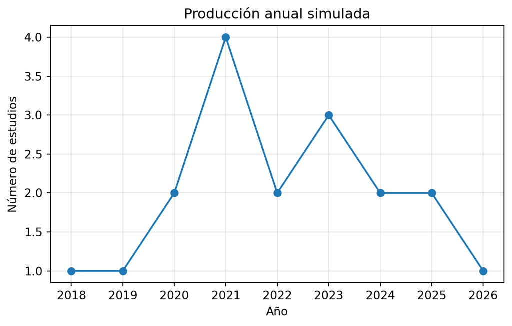

## Distribución por familia metodológica

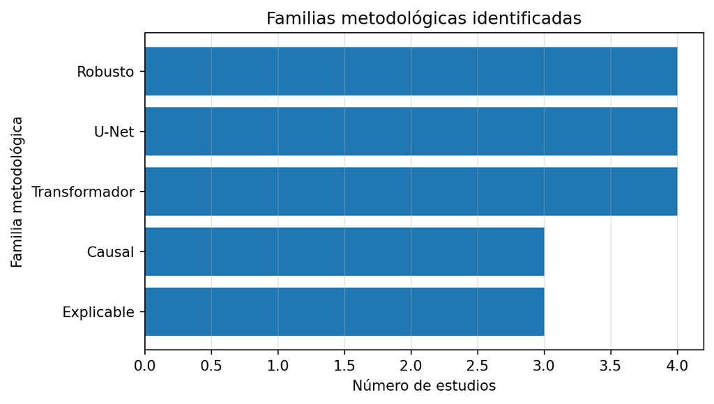

La frecuencia de una familia metodológica no equivale a superioridad científica. Puede indicar tradición, disponibilidad de código o facilidad de implementación.

## Gráfico de burbujas

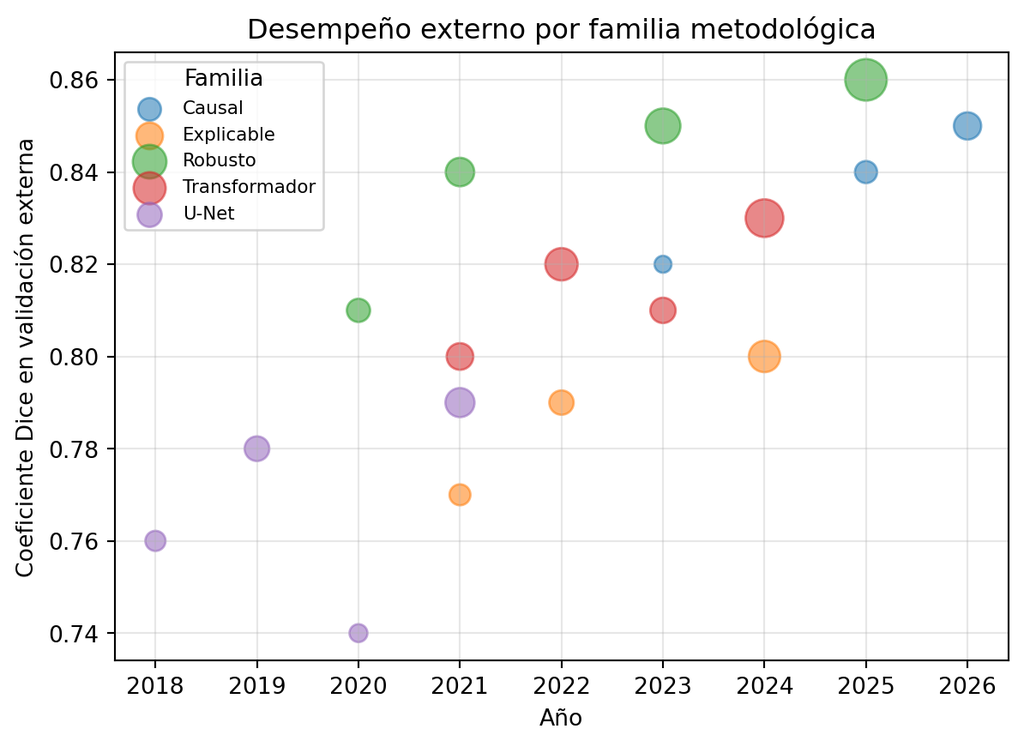

La burbuja representa tamaño muestral. El eje vertical representa desempeño externo. La lectura correcta exige combinar desempeño, tamaño de muestra y riesgo de sesgo.

## Caída intercentro

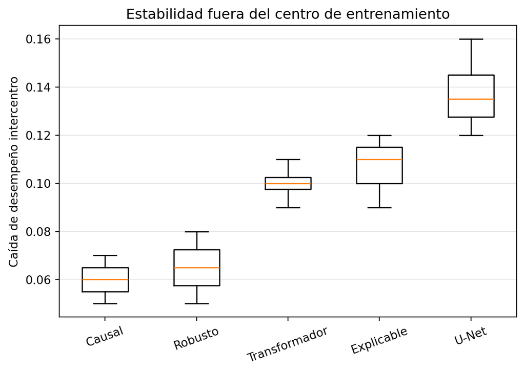

Menor caída intercentro sugiere mayor estabilidad. En este ejemplo, los enfoques robustos y causales muestran mejor estabilidad simulada.

## Evaluación crítica de estudios

| Criterio | Bajo riesgo | Riesgo moderado | Alto riesgo |
| --- | --- | --- | --- |
| Datos | Fuente, tamaño y partición claros | Fuente clara, partición incompleta | Fuente o partición ambigua |
| Validación | Externa independiente | Interna con partición razonable | Posible fuga de datos |
| Métricas | Dice, sensibilidad, precisión e intervalos | Métricas principales sin intervalo | Métrica global insuficiente |
| Preprocesamiento | Totalmente descrito | Parcialmente descrito | No descrito |
| Código o reproducibilidad | Código o protocolo disponible | Descripción suficiente | No reproducible |

## Matriz de extracción

|  | Estudio | Familia | Año | Pacientes | Dice externo | Caída intercentro | Riesgo de sesgo |
| --- | --- | --- | --- | --- | --- | --- | --- |
| 0 | E01 | U-Net | 2018 | 120 | 0.76 | 0.14 | Alto |
| 1 | E02 | U-Net | 2019 | 180 | 0.78 | 0.13 | Moderado |
| 2 | E03 | U-Net | 2020 | 95 | 0.74 | 0.16 | Alto |
| 3 | E04 | U-Net | 2021 | 250 | 0.79 | 0.12 | Moderado |
| 4 | E05 | Transformador | 2021 | 210 | 0.80 | 0.11 | Moderado |
| 5 | E06 | Transformador | 2022 | 310 | 0.82 | 0.10 | Bajo |
| 6 | E07 | Transformador | 2023 | 190 | 0.81 | 0.10 | Moderado |
| 7 | E08 | Transformador | 2024 | 420 | 0.83 | 0.09 | Bajo |
| 8 | E09 | Robusto | 2020 | 160 | 0.81 | 0.08 | Moderado |
| 9 | E10 | Robusto | 2021 | 240 | 0.84 | 0.07 | Bajo |
| 10 | E11 | Robusto | 2023 | 360 | 0.85 | 0.06 | Bajo |
| 11 | E12 | Robusto | 2025 | 510 | 0.86 | 0.05 | Bajo |
| 12 | E13 | Explicable | 2021 | 130 | 0.77 | 0.12 | Moderado |
| 13 | E14 | Explicable | 2022 | 175 | 0.79 | 0.11 | Moderado |
| 14 | E15 | Explicable | 2024 | 290 | 0.80 | 0.09 | Bajo |
| 15 | E16 | Causal | 2023 | 85 | 0.82 | 0.07 | Moderado |
| 16 | E17 | Causal | 2025 | 145 | 0.84 | 0.06 | Bajo |
| 17 | E18 | Causal | 2026 | 220 | 0.85 | 0.05 | Bajo |

## Síntesis por familia

|  | familia | estudios | pacientes_mediana | dice_mediano | caida_mediana |
| --- | --- | --- | --- | --- | --- |
| 2 | Robusto | 4 | 300.0 | 0.845 | 0.065 |
| 0 | Causal | 3 | 145.0 | 0.840 | 0.060 |
| 3 | Transformador | 4 | 260.0 | 0.815 | 0.100 |
| 1 | Explicable | 3 | 175.0 | 0.790 | 0.110 |
| 4 | U-Net | 4 | 150.0 | 0.770 | 0.135 |

## Interpretación de la síntesis

| Familia | Lectura metodológica |
| --- | --- |
| U-Net | Base comparativa sólida, pero con mayor caída intercentro en este ejemplo |
| Transformador | Mejor representación global, con mayor demanda de datos |
| Robusto | Mejor estabilidad simulada fuera del dominio original |
| Explicable | Aporta interpretabilidad, pero no siempre mejora desempeño |
| Causal | Prometedor para generalización, aunque con menor volumen de estudios |

La conclusión no debe ser “el modelo causal es mejor” de forma automática. La conclusión correcta es que, bajo estos datos simulados, los enfoques robustos y causales justifican mayor investigación comparativa con validación externa.

## Diagrama de cosecha

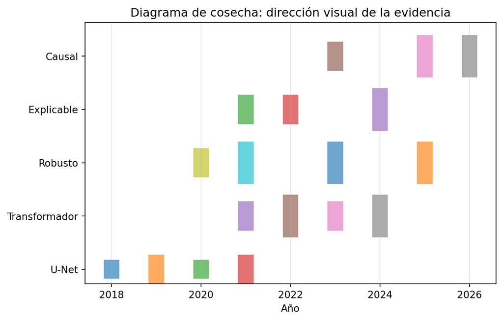

En un diagrama de cosecha, la altura puede representar calidad metodológica. Aquí, mayor altura indica menor riesgo de sesgo.

## Brechas accionables

| Brecha | Evidencia ilustrativa | Implicación |
| --- | --- | --- |
| Validación externa insuficiente | No todos los estudios reportan prueba intercentro | Exigir conjuntos independientes |
| Comparaciones no equivalentes | Diferentes particiones y preprocesamientos | Diseñar protocolos comunes |
| Explicabilidad incompleta | Se muestran mapas, pero no se valida su utilidad | Evaluar estabilidad y plausibilidad clínica |
| Causalidad débilmente formalizada | Algunos estudios usan el término causal sin grafo ni intervención | Separar robustez, asociación e inferencia causal |

## Conclusión ilustrativa

El flujo permite pasar de una pregunta amplia a una síntesis metodológicamente defendible.

## Producto final esperado

| Sección del informe | Contenido mínimo |
| --- | --- |
| Introducción | Justificación, pregunta y alcance |
| Métodos | Protocolo, búsqueda, selección y extracción |
| Bibliometría | Producción, familias, redes e indicadores |
| Evaluación crítica | Riesgo de sesgo y reproducibilidad |
| Síntesis | Comparación por familias metodológicas |
| Discusión | Brechas, limitaciones e implicaciones |
| Conclusión | Mensaje técnico sustentado |

## Mensaje de cierre

Un estado del arte riguroso no se construye acumulando referencias. Se construye documentando decisiones, comparando evidencia y separando tres niveles: presencia bibliográfica, calidad metodológica y valor explicativo.